# One-Predictor Linear Model Example

STAT 341, Spring 2023

2023-02-15

## Dataset and Plan

I will use the dataset on bridge condition.

```r
bridges <- read.csv("https://sldr.netlify.app/data/bridges.csv") |>
  # remove closed bridges (Condition.Rating = 0)
  filter(Condition.Rating >= 1) |>
  # remove bridges supposedly built after data collection
  filter(Year.Built <= 2015)
```

## Predictor & Response

I will model `Condition.Rating` as a function of `Year.Built`, thinking that newer bridges may be in better condition (and condition may deteriorate as the bridge ages).

## Causal Diagram

I think that older age will result in deteriorated bridge condition. Condition will vary by location and owner (and bridge age may be different depending on location and owner too). It seems there are bridges of different types and sizes; different kinds of bridges may be built more at certain times than others, and bridge type may vary by location too. Bridge type may affect condition and also interact with age (with the amount of deterioration with age being different for different bridge types). *Note, the graph below can’t depict the interaction - but note it makes Type a modifier of the age - condition relationship.*

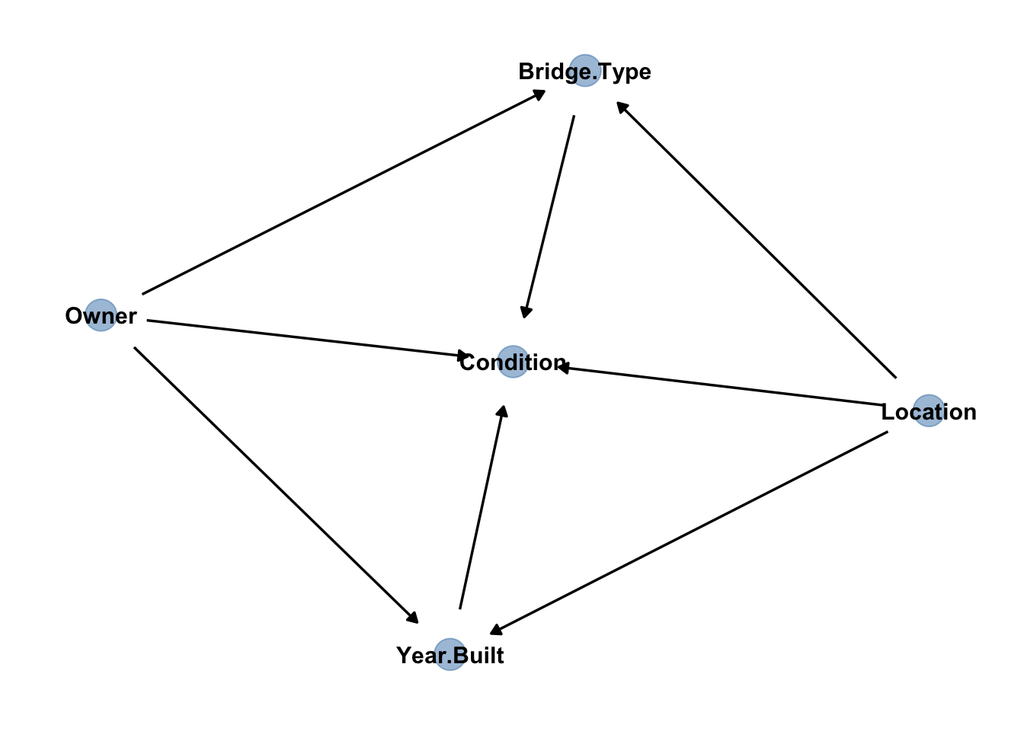

So: modeling condition as a function of just age is clearly an oversimplification, and leaves out key confounders and a moderator! (*Wish we already knew how to include more variables in our model…*)

## Model Description

$$\text{Condition}_i \sim
\text{Normal}(\mu_i, \sigma)$$
$$\mu_i
\sim \beta_0 + \beta_1 * \text{Year.Built}$$
$$\beta_0 \sim \text{Normal}(-186.5,50)$$
$$\beta_1 \sim \text{Normal}(0.1, 1)$$
$$\sigma \sim \text{Normal}(1.5,
2)$$

Rationale:

- Condition ratings go from 1 to 7. I expect them to go down year to year but to take well over a year (maybe 10 years or so?) to deteriorate a level on the scale.
- The intercept is the expected condition rating of a bridge built in year 0. I guess the oldest bridges in the data might have been built between the 1800s and 1950, and might have a condition rating that is low like 1-2. So if $\beta_1$ is about 0.1, and I want condition for an 1800 bridge to be about 1. Condition = 1 = $\beta_0 + \beta_1 *$ 1800, and that would make $\beta_0$ = 1 - 0.1 * 1800 = -179. Or if the oldest bridge was in 1950, I would be $\beta_0 = -194$. So I’ll center the prior for the intercept at 186.5 and give it a standard deviation of about 50 because I really could be off by an order of magnitude if my slope guess is wrong.
- There might be a lot of variation in condition ratings that doesn’t have to do with age alone. So I’ll make $\sigma$ centered at 1.5 (on a scale of 1-7) with a standard deviation of 2, so observed datapoints might be up to 4 or 6 condition units away from the expected value.